# Gapminder_analyses

Benjamin Weiner

10/4/2015

## Demographic analyses with R

These are analyses of the Gapminder demographic data using Rstudio.

The document and plots are produced using R markdown language.

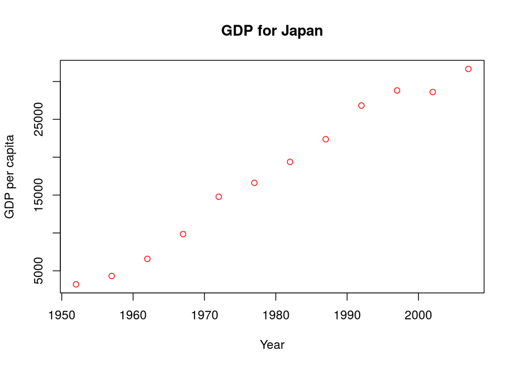

Japan’s GDP shows substantial growth after WWII until a period of stagnation beginning in the 1990s.

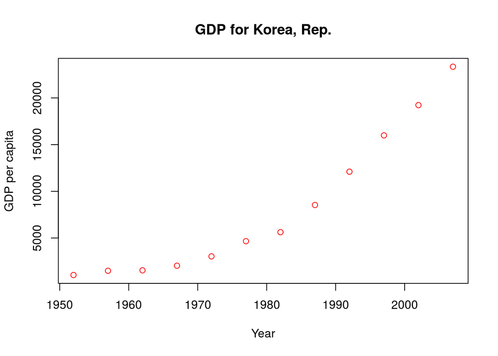

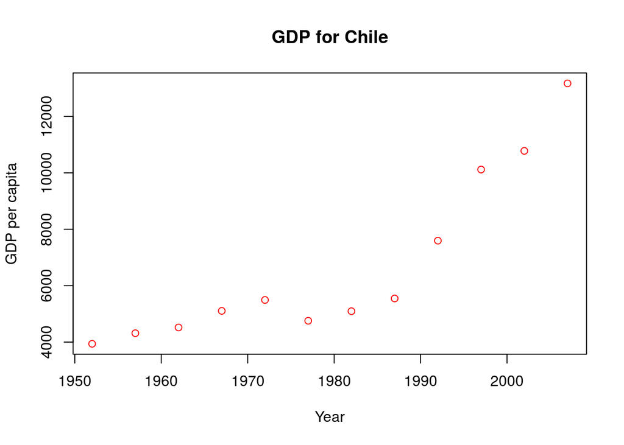

Chile’s GDP plot shows slow growth and an actual decline in the late 1970s, probably related to the coup and military government, until beginning a steep incrase in the 1990s after the return to democratic government.

```
## Source: local data frame [5 x 2]
##
##   continent     mean
##      (fctr)    (dbl)
## 1    Africa 50.60397
## 2  Americas 69.50691
## 3      Asia 61.11856
## 4    Europe 72.30718
## 5   Oceania 75.48954
```

```
## Source: local data frame [5 x 2]
##
##   continent      mean
##      (fctr)     (dbl)
## 1    Africa  2109.952
## 2  Americas 15477.067
## 3      Asia  2949.604
## 4    Europe 15692.823
## 5   Oceania 21204.964
```

[figure not shown]

```r
print(avglife)
```

```
## Source: local data frame [5 x 2]
##
##   continent     mean
##      (fctr)    (dbl)
## 1    Africa 50.60397
## 2  Americas 69.50691
## 3      Asia 61.11856
## 4    Europe 72.30718
## 5   Oceania 75.48954
```

```r
print(avggdp)
```

```
## Source: local data frame [5 x 2]
##
##   continent      mean
##      (fctr)     (dbl)
## 1    Africa  2109.952
## 2  Americas 15477.067
## 3      Asia  2949.604
## 4    Europe 15692.823
## 5   Oceania 21204.964
```

The mean life expectancy varies greatly from continent to continent and is correlated with GDP per capita.

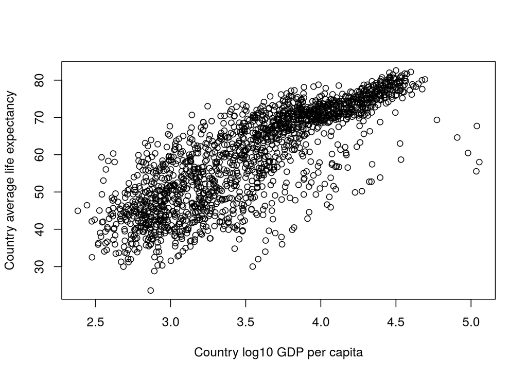

On a country by country basis there is a strong correlation between log GDP per capita and life expectancy, with some possibly interesting low outliers.

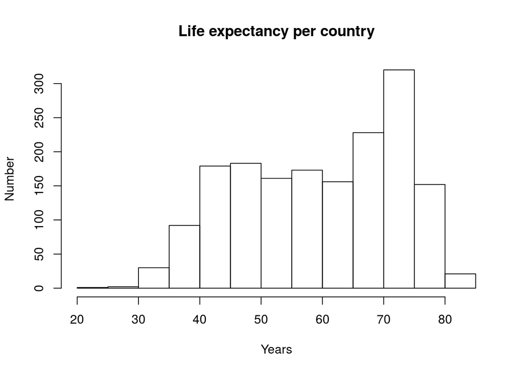

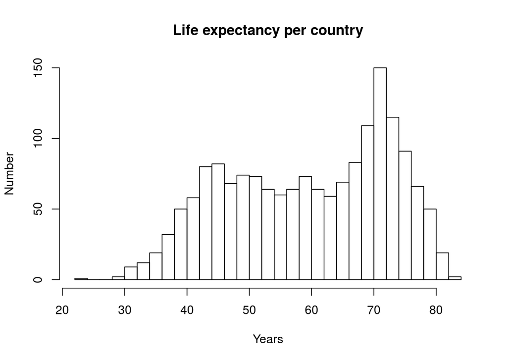

The life expectancy histogram is skewed, with a long tail towards short life expectancy. The finer-scale histogram shows that the tail is not steadily declining, but there is a plateau, or even a second peak around 40-50 years, and then a strong decline with few countries below 40 years.